# [DL]DeepLearning-Part2

按照自己的理解,写的入门水平的deep learning基础 Convolution Neural Network

### 特殊的网络结构

**卷积神经网络**
卷积神经网络是如何计算的非常简单。但还是先简单说说数学中的卷积是怎么回事(详细可以参考[wiki](https://en.wikipedia.org/wiki/Convolution))，再回过头来则能更好理解卷积神经网络。
卷积在数学中大概是说，两个函数通过做卷积，可以生成一个新的函数。我用两个最简单的函数画图示范一下 $$函数1：f(x)=\begin{cases} x & \text{ if } x \geq 0\\ 0 & \text{ if } x < 0 \end{cases}$$ $$函数2：g(x)=\begin{cases} 1 & \text{ if } 0 \leq x \leq 1\\ 0 & \text{ if } x= others \end{cases}$$ 把他们画下来就是：

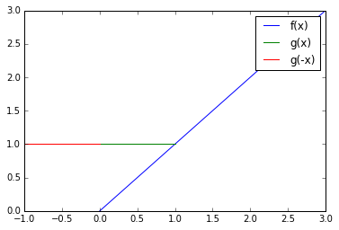

```python
import numpy as np
import matplotlib.pyplot as plt
%matplotlib inline
x1 = np.linspace(0, 3, 30)
y1 = x1
x2 = np.linspace(0, 1, 2)
y2 = np.ones_like(x2)
plt.plot(x1, y1, label="f(x)")
plt.plot(x2, y2, label="g(x)")
plt.plot(-x2, y2, label="g(-x)")
plt.legend()
plt.show()
```

对f(x),g(x)做卷积，公式为： $$(f*g)(t) = \int_{-\infty }^{+\infty }f(x)g(t-x)dx$$ 现在来解释这个式子对于上边的f(x)和g(x)来说，到底做了什么操作？
现在设想我们要求$(f*g)(t=0)$的值，那么卷积： $$(f*g)(t=0) = \int_{-\infty }^{+\infty }f(x)g(-x)dx$$ 从上边图可以看出f(x)g(-x)乘积为0，因此积分也为0。 再假设我们要求t=0.5时卷积的值，那么卷积： $$(f*g)(t=0.5) = \int_{-\infty }^{+\infty }f(x)g(0.5-x)dx$$ 把f(x)和g(0.5-x)在图上画出来：

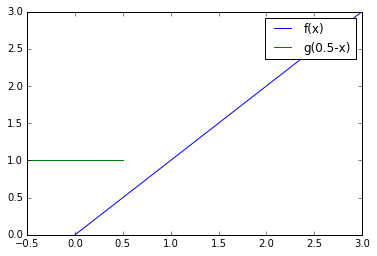

```python
x1 = np.linspace(0, 3, 30)
y1 = x1
x2 = np.linspace(-0.5, 0.5, 2)
y2 = np.ones_like(x2)
plt.plot(x1, y1, label="f(x)")
plt.plot(x2, y2, label="g(0.5-x)")
plt.legend()
plt.show()
```

因此f(x)和g(0.5-x)的相乘之后的积分，就是f(x)在0<x<0.5与x轴围成的面积，等于0.125。  
然后，我们可以假设t=0.6,0.7,0.8,...是不是已经看出来了，这个卷积就是g(-x)这个函数在向右移动，然后与f(x)做乘积，最后积分。然后如果f(x)和g(x)都是离散函数的话，就把积分号改成求和即可。  
现在回到卷积神经网络中来，假设现在有一张图片是单通道(如只有灰度)，大小为4×4px，这个图片就是上面的f(x)，图片每个像素点的位置就是自变量，每个像素点的值就是因变量。然后还有另外一个图片(不算真正意义的图片)，只有2×2px大小，就相当于上边的g(x)。然后他们做卷积，注意这里f和g都是离散函数。我把卷积的过程画下来了，如下图：

[figure not shown]

[figure not shown]

就是在原图片上边和左边补了一些0。问题差不多解决了，但是如果当原始图片比较大的时候，还是有些问题，因为如果原始图片是1028×1028px尺寸，做了好几层卷积之后，图片尺寸还是同样大小，这个对于计算来说，消耗太大。在CNN中是通过Pooling操作来解决这个问题的，pooling操作是在卷积操作之后进行的操作，然后通过pooling处理之后，再将结果给下一层卷积层。这里得说明一下，每层的卷积操作后，需要对每个卷积结果通过激活函数的处理。下边我会给一张图说明整个过程。现在用下图示意max pooling，他是pooling操作的一种，下面再解释

[figure not shown]

pooling就是一个用一个类似补丁的东西，去挨个"贴"一下原始图片同样大小范围的像素点，然后对这批落在补丁范围内的像素点进行计算求值。max pooling就是计算时，取补丁范围内像素点的最大值。当然啦， 这个补丁是可以根据需要调整大小的，而且可以选择每次补丁移动的步长，这里每次移动了2个像素点。  
现在整体说下CNN的流程，画这个难度有点太大，从网上copy了一张图，如下：

[figure not shown]

1. 首先对原始图像进行了卷积，这个图片里是使用了三个卷积核，生成了三张新的“图片”，其中对新"图片"，每个像素点都通过了激活函数处理
2. 然后使用pooling操作，将"图片"尺寸大为减小，但是"图片"数量没有变化
3. 将上一步pooling的结果，当作全新的“图片”，开始新一轮的卷积，然后pooling
4. 完成所有卷积和pooling层之后，一般会将图片flatten成一维的向量，然后进行和运用在普通神经网络结构上相似的操作，如来几个全连接层，最后弄个softmax层。

这里说说使用卷积的意义，首先卷积是一种局部连接，对于图片这种输入数据维度很大，网络层数很多的情况，使用全连接恐怕是不行的，然后这种局部连接不仅仅是可以减少计算负担，而且还类似人脑视觉神经科学中解释的人的视觉工作原理，我的理解，一张图片中的信息量很大，但是我们关注的可能只是局部的某一块，比如人脸识别，整张图片人脸所占的比例还是比较小的，然后我们在识别人脸的时候，也不是一个像素一个像素的比对，而是发现了这个眼睛像谁，然后眉毛，嘴巴也正好像他，那我们就可以判断这个人脸就是他。而使用卷积正好方便这种局部特征的抽取。

继续请看DeepLearning-part3